# Modelagem Preditiva em IoT - Previsão de Uso de Energia

# Definição projeto

Este projeto de IoT tem como objetivo a criação de modelos preditivos para a previsão de consumo de energia de eletrodomésticos. Os dados utilizados incluem medições de sensores de temperatura e umidade de uma rede sem fio,previsão do tempo de uma estação de um aeroporto e uso de energia utilizada por luminárias.

Nesse projeto de aprendizado de máquina você deve realizar a filtragem de dados para remover parâmetros não-preditivos e selecionar os melhores recursos (melhores features) para previsão. O conjunto de dados foi coletado por um período de 10 minutos por cerca de 5 meses. As condições de temperatura e umidade da casa foram monitoradas com uma rede de sensores sem fio ZigBee.

Cada nó sem fio transmitia as condições de temperatura e umidade em torno de 3 min. Em seguida, a média dos dados foi calculada para períodos de 10 minutos. Os dados de energia foram registrados a cada 10 minutos com medidores de energia de barramento m. O tempo da estação meteorológica mais próxima do aeroporto (Aeroporto de Chievres, Bélgica) foi baixado de um conjunto de dados públicos do Reliable Prognosis (rp5.ru) e mesclado com os conjuntos de dados experimentais usando a coluna de data e hora. Duas variáveis aleatórias foram incluídas no conjunto de dados para testar os modelos de regressão e filtrar os atributos não preditivos (parâmetros).

# Objetivo

Seu trabalho agora é construir um modelo preditivo que possa prever o consumo de energia com base nos dados de sensores IoT coletados. Recomendamos usar Random Forest para a seleção de atributos e SVM, Regressão Logística Multilinear ou Gradient Boosting para o modelo preditivo. Recomendamos ainda o uso da linguagem R.

# Citação

Esse projeto da formação cientista de dados da @Data Science Academy

# Dicionario dados

date time = ano-mês-dia hora:minuto:segundo

Appliances = uso de energia em Wh (variável alvo para previsão)

lights = uso de energia de luminárias na casa em Wh

T1 = Temperatura na área da cozinha, em Celsius RH_1 = Umidade na área da cozinha, em %

T2 = Temperatura na zona da sala, em Celsius RH_2 = Umidade na área da sala, em %

T3 = Temperatura na zona da lavandaria RH_3 = Umidade na área da lavanderia, em %

T4 = Temperatura em sala de escritório, em Celsius RH_4 = Umidade na sala do escritório, em %

T5 = Temperatura no banheiro, em Celsius RH_5 = Umidade no banheiro, em %

T6 = Temperatura exterior ao edifício (lado norte), em Celsius RH_6 = Umidade externa ao edifício (lado norte), em %

T7 = Temperatura na sala de passar roupa, em Celsius RH_7 = Umidade na sala de passar roupa, em %

T8 = Temperatura no quarto do adolescente 2, em Celsius RH_8 = Umidade no quarto do adolescente 2, em %

T9 = Temperatura no quarto dos pais, em Celsius RH_9 = Umidade no quarto dos pais, em %

TO = Temperatura externa (da estação meteorológica de Chievres), em Celsius

Pressure = (da estação meteorológica de Chievres), em mm Hg

RH_out = umidade externa (da estação meteorológica de Chievres), em% Wind speed = Velocidade do vento (da estação meteorológica de Chievres), em m/s

Visibilidade = (da estação meteorológica de Chievres), em km Tdewpoint = (da estação meteorológica de Chievres), °C

rv1 = variável aleatória 1, adimensional rv2 = variável aleatória 2, adimensional

```r
## Importando as bibliotecas
library(readr)
library(dplyr)
```

```r
library(ggplot2)
library(corrplot)
library(lubridate)
library(lubridate)
library(caret)
library(randomForest)
library(xgboost)
library(forecast)
library(e1071)
library(class)
```

Dataset

```r
## Dataset
data_train <- read_csv("projeto8-training.csv")
data_test <- read_csv("projeto8-testing.csv")
# Visualizandos dados
head(data_train)
```

| date | Appliances | lights | T1 | RH_1 | T2 | RH_2 | T3 | RH_3 | T4 | RH_4 | T5 | RH_5 | T6 | RH_6 | T7 | RH_7 | T8 | RH_8 | T9 | RH_9 | T_out | Press_mm_hg | RH_out | Windspeed | Visibility | Tdewpoint | rv1 | rv2 | NSM | … |
| --- | --- | --- | --- | --- | --- | --- | --- | --- | --- | --- | --- | --- | --- | --- | --- | --- | --- | --- | --- | --- | --- | --- | --- | --- | --- | --- | --- | --- | --- | --- |
| 2016-01-11 17:00:00 | 60 | 30 | 19.89000 | 47.59667 | 19.2 | 44.79000 | 19.79 | 44.73000 | 19.00000 | 45.56667 | 17.16667 | 55.20 | 7.026667 | 84.25667 | 17.20000 | 41.62667 | 18.2 | 48.90000 | 17.03333 | 45.53 | 6.600000 | 733.5000 | 92.00000 | 7.000000 | 63.00000 | 5.300000 | 13.27543 | 13.27543 | 61200 | … |
| 2016-01-11 17:10:00 | 60 | 30 | 19.89000 | 46.69333 | 19.2 | 44.72250 | 19.79 | 44.79000 | 19.00000 | 45.99250 | 17.16667 | 55.20 | 6.833333 | 84.06333 | 17.20000 | 41.56000 | 18.2 | 48.86333 | 17.06667 | 45.56 | 6.483333 | 733.6000 | 92.00000 | 6.666667 | 59.16667 | 5.200000 | 18.60619 | 18.60619 | 61800 | … |
| 2016-01-11 17:20:00 | 50 | 30 | 19.89000 | 46.30000 | 19.2 | 44.62667 | 19.79 | 44.93333 | 18.92667 | 45.89000 | 17.16667 | 55.09 | 6.560000 | 83.15667 | 17.20000 | 41.43333 | 18.2 | 48.73000 | 17.00000 | 45.50 | 6.366667 | 733.7000 | 92.00000 | 6.333333 | 55.33333 | 5.100000 | 28.64267 | 28.64267 | 62400 | … |
| 2016-01-11 17:40:00 | 60 | 40 | 19.89000 | 46.33333 | 19.2 | 44.53000 | 19.79 | 45.00000 | 18.89000 | 45.53000 | 17.20000 | 55.09 | 6.366667 | 84.89333 | 17.20000 | 41.23000 | 18.1 | 48.59000 | 17.00000 | 45.40 | 6.133333 | 733.9000 | 92.00000 | 5.666667 | 47.66667 | 4.900000 | 10.08410 | 10.08410 | 63600 | … |
| 2016-01-11 17:50:00 | 50 | 40 | 19.89000 | 46.02667 | 19.2 | 44.50000 | 19.79 | 44.93333 | 18.89000 | 45.73000 | 17.13333 | 55.03 | 6.300000 | 85.76667 | 17.13333 | 41.26000 | 18.1 | 48.59000 | 17.00000 | 45.29 | 6.016667 | 734.0000 | 92.00000 | 5.333333 | 43.83333 | 4.800000 | 44.91948 | 44.91948 | 64200 | … |
| 2016-01-11 18:10:00 | 60 | 50 | 19.85667 | 45.56000 | 19.2 | 44.50000 | 19.73 | 44.90000 | 18.89000 | 45.86333 | 17.10000 | 54.90 | 6.190000 | 86.42333 | 17.10000 | 41.20000 | 18.1 | 48.59000 | 17.00000 | 45.29 | 5.916667 | 734.1667 | 91.83333 | 5.166667 | 40.00000 | 4.683333 | 33.03989 | 33.03989 | 65400 | … |

```r
head(data_test)
```

| date | Appliances | lights | T1 | RH_1 | T2 | RH_2 | T3 | RH_3 | T4 | RH_4 | T5 | RH_5 | T6 | RH_6 | T7 | RH_7 | T8 | RH_8 | T9 | RH_9 | T_out | Press_mm_hg | RH_out | Windspeed | Visibility | Tdewpoint | rv1 | rv2 | NSM | … |
| --- | --- | --- | --- | --- | --- | --- | --- | --- | --- | --- | --- | --- | --- | --- | --- | --- | --- | --- | --- | --- | --- | --- | --- | --- | --- | --- | --- | --- | --- | --- |
| 2016-01-11 17:30:00 | 50 | 40 | 19.89000 | 46.06667 | 19.20000 | 44.59000 | 19.79 | 45.00000 | 18.89 | 45.72333 | 17.16667 | 55.09000 | 6.433333 | 83.42333 | 17.13333 | 41.29000 | 18.10000 | 48.59000 | 17.00 | 45.40000 | 6.250000 | 733.8000 | 92.00000 | 6.000000 | 51.5 | 5.000000 | 45.410389 | 45.410389 | 63000 | … |
| 2016-01-11 18:00:00 | 60 | 50 | 19.89000 | 45.76667 | 19.20000 | 44.50000 | 19.79 | 44.90000 | 18.89 | 45.79000 | 17.10000 | 54.96667 | 6.263333 | 86.09000 | 17.13333 | 41.20000 | 18.10000 | 48.59000 | 17.00 | 45.29000 | 5.900000 | 734.1000 | 92.00000 | 5.000000 | 40.0 | 4.700000 | 47.233763 | 47.233763 | 64800 | … |
| 2016-01-11 18:40:00 | 230 | 70 | 19.92667 | 45.86333 | 19.35667 | 44.40000 | 19.79 | 44.90000 | 18.89 | 46.43000 | 17.10000 | 55.00000 | 6.190000 | 87.86667 | 17.24750 | 42.71750 | 18.10000 | 48.59000 | 17.00 | 45.29000 | 5.966667 | 734.3667 | 91.33333 | 5.666667 | 40.0 | 4.633333 | 10.298729 | 10.298729 | 67200 | … |
| 2016-01-11 18:50:00 | 580 | 60 | 20.06667 | 46.39667 | 19.42667 | 44.40000 | 19.79 | 44.82667 | 19.00 | 46.43000 | 17.10000 | 55.00000 | 6.123333 | 87.99333 | 17.53000 | 44.26333 | 18.06667 | 48.63333 | 16.89 | 45.29000 | 5.983333 | 734.4333 | 91.16667 | 5.833333 | 40.0 | 4.616667 | 8.827838 | 8.827838 | 67800 | … |
| 2016-01-11 19:30:00 | 100 | 10 | 20.56667 | 53.89333 | 20.03333 | 46.75667 | 20.10 | 48.46667 | 19.00 | 48.49000 | 17.15000 | 56.04250 | 5.800000 | 88.36667 | 17.89000 | 44.92667 | 18.15000 | 49.20000 | 16.89 | 45.32667 | 6.000000 | 734.8500 | 89.50000 | 6.000000 | 40.0 | 4.350000 | 24.884962 | 24.884962 | 70200 | … |
| 2016-01-11 19:50:00 | 70 | 30 | 20.85667 | 53.66000 | 20.20000 | 47.05667 | 20.20 | 48.44750 | 18.89 | 47.96333 | 17.20000 | 56.93333 | 5.526667 | 87.30000 | 17.70000 | 43.72667 | 18.35667 | 50.02667 | 16.89 | 45.29000 | 6.000000 | 735.0833 | 88.50000 | 6.000000 | 40.0 | 4.183333 | 49.595305 | 49.595305 | 71400 | … |

```r
# Visualizando 5 últimos dados
tail(data_train)
```

| date | Appliances | lights | T1 | RH_1 | T2 | RH_2 | T3 | RH_3 | T4 | RH_4 | T5 | RH_5 | T6 | RH_6 | T7 | RH_7 | T8 | RH_8 | T9 | RH_9 | T_out | Press_mm_hg | RH_out | Windspeed | Visibility | Tdewpoint | rv1 | rv2 | NSM | … |
| --- | --- | --- | --- | --- | --- | --- | --- | --- | --- | --- | --- | --- | --- | --- | --- | --- | --- | --- | --- | --- | --- | --- | --- | --- | --- | --- | --- | --- | --- | --- |
| 2016-05-27 16:50:00 | 120 | 0 | 25.50000 | 47.45667 | 26.00000 | 42.32000 | 27.66333 | 40.69333 | 24.7 | 45.56000 | 23.20 | 52.12667 | 25.83333 | 1 | 24.46857 | 44.66857 | 24.54000 | 51.50000 | 23.2 | 46.71800 | 22.96667 | 755.25 | 55.00000 | 2.833333 | 22.16667 | 13.36667 | 1.796395 | 1.796395 | 60600 | … |
| 2016-05-27 17:00:00 | 110 | 0 | 25.60000 | 47.19333 | 25.96857 | 42.52857 | 27.39000 | 41.03000 | 24.7 | 45.62667 | 23.20 | 52.26000 | 25.96333 | 1 | 24.50000 | 44.71800 | 24.60000 | 50.86333 | 23.2 | 46.75143 | 23.00000 | 755.20 | 55.00000 | 3.000000 | 22.00000 | 13.40000 | 18.248201 | 18.248201 | 61200 | … |
| 2016-05-27 17:10:00 | 90 | 0 | 25.53333 | 46.86000 | 25.97800 | 42.53400 | 27.32333 | 41.09000 | 24.7 | 45.62667 | 23.20 | 52.32667 | 25.63000 | 1 | 24.50000 | 44.76429 | 24.66667 | 50.44500 | 23.2 | 46.74500 | 22.86667 | 755.20 | 55.33333 | 3.166667 | 22.83333 | 13.36667 | 16.966162 | 16.966162 | 61800 | … |
| 2016-05-27 17:30:00 | 90 | 0 | 25.50000 | 46.50000 | 25.75400 | 42.08000 | 27.13333 | 41.22333 | 24.7 | 45.59000 | 23.23 | 52.32667 | 24.19667 | 1 | 24.55714 | 44.41429 | 24.70000 | 49.79000 | 23.2 | 46.79000 | 22.60000 | 755.20 | 56.00000 | 3.500000 | 24.50000 | 13.30000 | 49.282940 | 49.282940 | 63000 | … |
| 2016-05-27 17:50:00 | 420 | 10 | 25.50000 | 46.99000 | 25.41400 | 43.03600 | 26.89000 | 41.29000 | 24.7 | 45.79000 | 23.20 | 52.20000 | 22.43333 | 1 | 24.50000 | 44.29571 | 24.66250 | 49.51875 | 23.2 | 46.81750 | 22.33333 | 755.20 | 56.66667 | 3.833333 | 26.16667 | 13.23333 | 6.322784 | 6.322784 | 64200 | … |
| 2016-05-27 18:00:00 | 430 | 10 | 25.50000 | 46.60000 | 25.26429 | 42.97143 | 26.82333 | 41.15667 | 24.7 | 45.96333 | 23.20 | 52.20000 | 21.02667 | 1 | 24.50000 | 44.05400 | 24.73600 | 49.73600 | 23.2 | 46.84500 | 22.20000 | 755.20 | 57.00000 | 4.000000 | 27.00000 | 13.20000 | 34.118851 | 34.118851 | 64800 | … |

```r
# View dados
View(data_train)
```

```r
View(data_test)
```

```r
# Verifique as primeiras linhas dos dados
head(data_train)
```

| date | Appliances | lights | T1 | RH_1 | T2 | RH_2 | T3 | RH_3 | T4 | RH_4 | T5 | RH_5 | T6 | RH_6 | T7 | RH_7 | T8 | RH_8 | T9 | RH_9 | T_out | Press_mm_hg | RH_out | Windspeed | Visibility | Tdewpoint | rv1 | rv2 | NSM | … |
| --- | --- | --- | --- | --- | --- | --- | --- | --- | --- | --- | --- | --- | --- | --- | --- | --- | --- | --- | --- | --- | --- | --- | --- | --- | --- | --- | --- | --- | --- | --- |
| 2016-01-11 17:00:00 | 60 | 30 | 19.89000 | 47.59667 | 19.2 | 44.79000 | 19.79 | 44.73000 | 19.00000 | 45.56667 | 17.16667 | 55.20 | 7.026667 | 84.25667 | 17.20000 | 41.62667 | 18.2 | 48.90000 | 17.03333 | 45.53 | 6.600000 | 733.5000 | 92.00000 | 7.000000 | 63.00000 | 5.300000 | 13.27543 | 13.27543 | 61200 | … |
| 2016-01-11 17:10:00 | 60 | 30 | 19.89000 | 46.69333 | 19.2 | 44.72250 | 19.79 | 44.79000 | 19.00000 | 45.99250 | 17.16667 | 55.20 | 6.833333 | 84.06333 | 17.20000 | 41.56000 | 18.2 | 48.86333 | 17.06667 | 45.56 | 6.483333 | 733.6000 | 92.00000 | 6.666667 | 59.16667 | 5.200000 | 18.60619 | 18.60619 | 61800 | … |
| 2016-01-11 17:20:00 | 50 | 30 | 19.89000 | 46.30000 | 19.2 | 44.62667 | 19.79 | 44.93333 | 18.92667 | 45.89000 | 17.16667 | 55.09 | 6.560000 | 83.15667 | 17.20000 | 41.43333 | 18.2 | 48.73000 | 17.00000 | 45.50 | 6.366667 | 733.7000 | 92.00000 | 6.333333 | 55.33333 | 5.100000 | 28.64267 | 28.64267 | 62400 | … |
| 2016-01-11 17:40:00 | 60 | 40 | 19.89000 | 46.33333 | 19.2 | 44.53000 | 19.79 | 45.00000 | 18.89000 | 45.53000 | 17.20000 | 55.09 | 6.366667 | 84.89333 | 17.20000 | 41.23000 | 18.1 | 48.59000 | 17.00000 | 45.40 | 6.133333 | 733.9000 | 92.00000 | 5.666667 | 47.66667 | 4.900000 | 10.08410 | 10.08410 | 63600 | … |
| 2016-01-11 17:50:00 | 50 | 40 | 19.89000 | 46.02667 | 19.2 | 44.50000 | 19.79 | 44.93333 | 18.89000 | 45.73000 | 17.13333 | 55.03 | 6.300000 | 85.76667 | 17.13333 | 41.26000 | 18.1 | 48.59000 | 17.00000 | 45.29 | 6.016667 | 734.0000 | 92.00000 | 5.333333 | 43.83333 | 4.800000 | 44.91948 | 44.91948 | 64200 | … |
| 2016-01-11 18:10:00 | 60 | 50 | 19.85667 | 45.56000 | 19.2 | 44.50000 | 19.73 | 44.90000 | 18.89000 | 45.86333 | 17.10000 | 54.90 | 6.190000 | 86.42333 | 17.10000 | 41.20000 | 18.1 | 48.59000 | 17.00000 | 45.29 | 5.916667 | 734.1667 | 91.83333 | 5.166667 | 40.00000 | 4.683333 | 33.03989 | 33.03989 | 65400 | … |

```r
# Verifique a estrutura dos dados
str(data_train)
```

```
## spc_tbl_ [14,803 × 32] (S3: spec_tbl_df/tbl_df/tbl/data.frame)
##  $ date       : POSIXct[1:14803], format: "2016-01-11 17:00:00" "2016-01-11 17:10:00" ...
##  $ Appliances : num [1:14803] 60 60 50 60 50 60 60 70 430 250 ...
##  $ lights     : num [1:14803] 30 30 30 40 40 50 40 40 50 40 ...
##  $ T1         : num [1:14803] 19.9 19.9 19.9 19.9 19.9 ...
##  $ RH_1       : num [1:14803] 47.6 46.7 46.3 46.3 46 ...
##  $ T2         : num [1:14803] 19.2 19.2 19.2 19.2 19.2 ...
##  $ RH_2       : num [1:14803] 44.8 44.7 44.6 44.5 44.5 ...
##  $ T3         : num [1:14803] 19.8 19.8 19.8 19.8 19.8 ...
##  $ RH_3       : num [1:14803] 44.7 44.8 44.9 45 44.9 ...
##  $ T4         : num [1:14803] 19 19 18.9 18.9 18.9 ...
##  $ RH_4       : num [1:14803] 45.6 46 45.9 45.5 45.7 ...
##  $ T5         : num [1:14803] 17.2 17.2 17.2 17.2 17.1 ...
##  $ RH_5       : num [1:14803] 55.2 55.2 55.1 55.1 55 ...
##  $ T6         : num [1:14803] 7.03 6.83 6.56 6.37 6.3 ...
##  $ RH_6       : num [1:14803] 84.3 84.1 83.2 84.9 85.8 ...
##  $ T7         : num [1:14803] 17.2 17.2 17.2 17.2 17.1 ...
##  $ RH_7       : num [1:14803] 41.6 41.6 41.4 41.2 41.3 ...
##  $ T8         : num [1:14803] 18.2 18.2 18.2 18.1 18.1 ...
##  $ RH_8       : num [1:14803] 48.9 48.9 48.7 48.6 48.6 ...
##  $ T9         : num [1:14803] 17 17.1 17 17 17 ...
##  $ RH_9       : num [1:14803] 45.5 45.6 45.5 45.4 45.3 ...
##  $ T_out      : num [1:14803] 6.6 6.48 6.37 6.13 6.02 ...
##  $ Press_mm_hg: num [1:14803] 734 734 734 734 734 ...
##  $ RH_out     : num [1:14803] 92 92 92 92 92 ...
##  $ Windspeed  : num [1:14803] 7 6.67 6.33 5.67 5.33 ...
##  $ Visibility : num [1:14803] 63 59.2 55.3 47.7 43.8 ...
##  $ Tdewpoint  : num [1:14803] 5.3 5.2 5.1 4.9 4.8 ...
##  $ rv1        : num [1:14803] 13.3 18.6 28.6 10.1 44.9 ...
##  $ rv2        : num [1:14803] 13.3 18.6 28.6 10.1 44.9 ...
##  $ NSM        : num [1:14803] 61200 61800 62400 63600 64200 65400 66000 66600 68400 69000 ...
##  $ WeekStatus : chr [1:14803] "Weekday" "Weekday" "Weekday" "Weekday" ...
##  $ Day_of_week: chr [1:14803] "Monday" "Monday" "Monday" "Monday" ...
##  - attr(*, "spec")=
##   .. cols(
##   ..   date = col_datetime(format = ""),
##   ..   Appliances = col_double(),
##   ..   lights = col_double(),
##   ..   T1 = col_double(),
##   ..   RH_1 = col_double(),
```

[output cut: 14 more lines]

```
##   ..   T9 = col_double(),
##   ..   RH_9 = col_double(),
##   ..   T_out = col_double(),
##   ..   Press_mm_hg = col_double(),
##   ..   RH_out = col_double(),
##   ..   Windspeed = col_double(),
##   ..   Visibility = col_double(),
##   ..   Tdewpoint = col_double(),
##   ..   rv1 = col_double(),
##   ..   rv2 = col_double(),
##   ..   NSM = col_double(),
##   ..   WeekStatus = col_character(),
##   ..   Day_of_week = col_character()
##   .. )
##  - attr(*, "problems")=<externalptr>
```

```r
# Verifique se há valores ausentes
sum(is.na(data_train))
```

```
## [1] 0
```

Análise dados

```r
# Resumo estatístico das variáveis numéricas:
summary(data_train)
```

```
##       date                          Appliances          lights
##  Min.   :2016-01-11 17:00:00.00   Min.   :  10.00   Min.   : 0.000
##  1st Qu.:2016-02-14 22:55:00.00   1st Qu.:  50.00   1st Qu.: 0.000
##  Median :2016-03-19 20:20:00.00   Median :  60.00   Median : 0.000
##  Mean   :2016-03-20 02:37:28.56   Mean   :  98.01   Mean   : 3.803
##  3rd Qu.:2016-04-23 06:55:00.00   3rd Qu.: 100.00   3rd Qu.: 0.000
##  Max.   :2016-05-27 18:00:00.00   Max.   :1080.00   Max.   :50.000
##        T1             RH_1             T2             RH_2
##  Min.   :16.79   Min.   :27.02   Min.   :16.10   Min.   :20.89
##  1st Qu.:20.73   1st Qu.:37.36   1st Qu.:18.82   1st Qu.:37.90
##  Median :21.60   Median :39.66   Median :20.00   Median :40.50
##  Mean   :21.68   Mean   :40.27   Mean   :20.34   Mean   :40.42
##  3rd Qu.:22.60   3rd Qu.:43.09   3rd Qu.:21.50   3rd Qu.:43.29
##  Max.   :26.26   Max.   :63.36   Max.   :29.86   Max.   :56.03
##        T3             RH_3             T4             RH_4
##  Min.   :17.20   Min.   :28.77   Min.   :15.10   Min.   :27.66
##  1st Qu.:20.79   1st Qu.:36.90   1st Qu.:19.50   1st Qu.:35.53
##  Median :22.10   Median :38.53   Median :20.67   Median :38.40
##  Mean   :22.26   Mean   :39.25   Mean   :20.86   Mean   :39.03
##  3rd Qu.:23.29   3rd Qu.:41.76   3rd Qu.:22.10   3rd Qu.:42.13
##  Max.   :29.24   Max.   :50.16   Max.   :26.20   Max.   :51.06
##        T5             RH_5             T6              RH_6
##  Min.   :15.33   Min.   :29.86   Min.   :-6.065   Min.   : 1.00
##  1st Qu.:18.27   1st Qu.:45.40   1st Qu.: 3.657   1st Qu.:30.10
##  Median :19.39   Median :49.09   Median : 7.295   Median :55.30
##  Mean   :19.59   Mean   :50.96   Mean   : 7.921   Mean   :54.62
##  3rd Qu.:20.60   3rd Qu.:53.66   3rd Qu.:11.245   3rd Qu.:83.33
##  Max.   :25.75   Max.   :95.95   Max.   :28.290   Max.   :99.90
##        T7             RH_7             T8             RH_8
##  Min.   :15.39   Min.   :23.20   Min.   :16.31   Min.   :29.60
##  1st Qu.:18.70   1st Qu.:31.50   1st Qu.:20.79   1st Qu.:39.06
##  Median :20.03   Median :34.82   Median :22.13   Median :42.36
##  Mean   :20.26   Mean   :35.39   Mean   :22.03   Mean   :42.92
##  3rd Qu.:21.60   3rd Qu.:39.00   3rd Qu.:23.39   3rd Qu.:46.56
##  Max.   :26.00   Max.   :51.40   Max.   :27.23   Max.   :58.78
##        T9             RH_9           T_out         Press_mm_hg
##  Min.   :14.89   Min.   :29.17   Min.   :-5.000   Min.   :729.3
##  1st Qu.:18.00   1st Qu.:38.50   1st Qu.: 3.667   1st Qu.:750.9
##  Median :19.39   Median :40.86   Median : 6.900   Median :756.1
##  Mean   :19.48   Mean   :41.54   Mean   : 7.413   Mean   :755.5
```

[output cut: 8 more lines]

```
##  Max.   :100.00   Max.   :13.500   Max.   :66.00   Max.   :15.500
##       rv1                rv2                NSM         WeekStatus
##  Min.   : 0.00532   Min.   : 0.00532   Min.   :    0   Length:14803
##  1st Qu.:12.58042   1st Qu.:12.58042   1st Qu.:21600   Class :character
##  Median :25.04399   Median :25.04399   Median :43200   Mode  :character
##  Mean   :25.07809   Mean   :25.07809   Mean   :42986
##  3rd Qu.:37.66591   3rd Qu.:37.66591   3rd Qu.:64800
##  Max.   :49.99653   Max.   :49.99653   Max.   :85800
##  Day_of_week
##  Length:14803
##  Class :character
##  Mode  :character
##
##
##
```

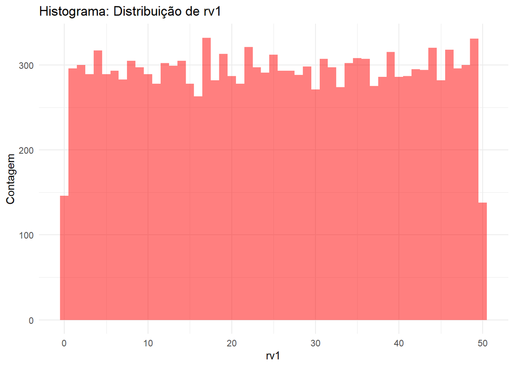

```r
# Gráfico váriavel alvo - rv1
ggplot(data_train, aes(x = rv1)) +
  geom_histogram(binwidth = 1, fill = "red", alpha = 0.5) +
  labs(x = "rv1", y = "Contagem", title = "Histograma: Distribuição de rv1") +
  theme_minimal()
```

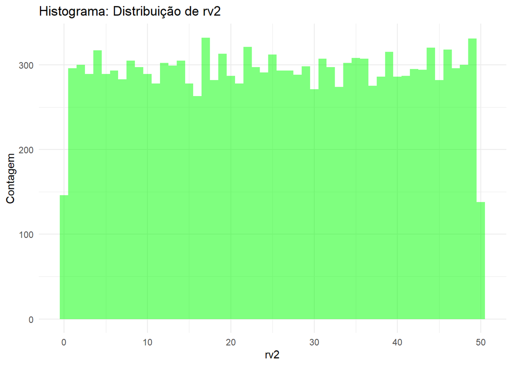

```r
# Gráfico váriavel alvo - rv2
ggplot(data_train, aes(x = rv2)) +
  geom_histogram(binwidth = 1, fill = "green", alpha = 0.5) +
  labs(x = "rv2", y = "Contagem", title = "Histograma: Distribuição de rv2") +
  theme_minimal()
```

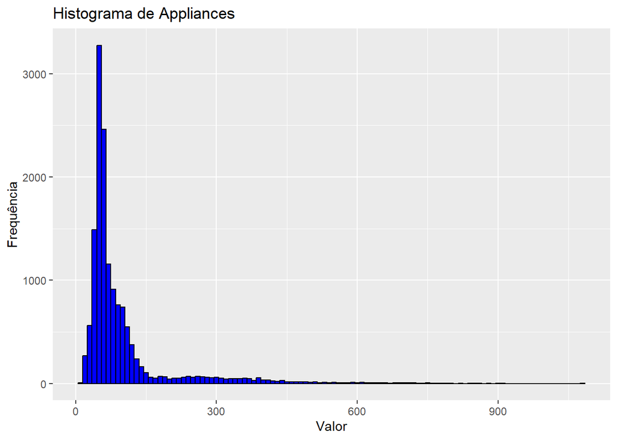

```r
# Gráfico Appliances
ggplot(data_train, aes(x = Appliances)) +
  geom_histogram(binwidth = 10, fill = "blue", color = "black") +
  labs(title = "Histograma de Appliances", x = "Valor", y = "Frequência")
```

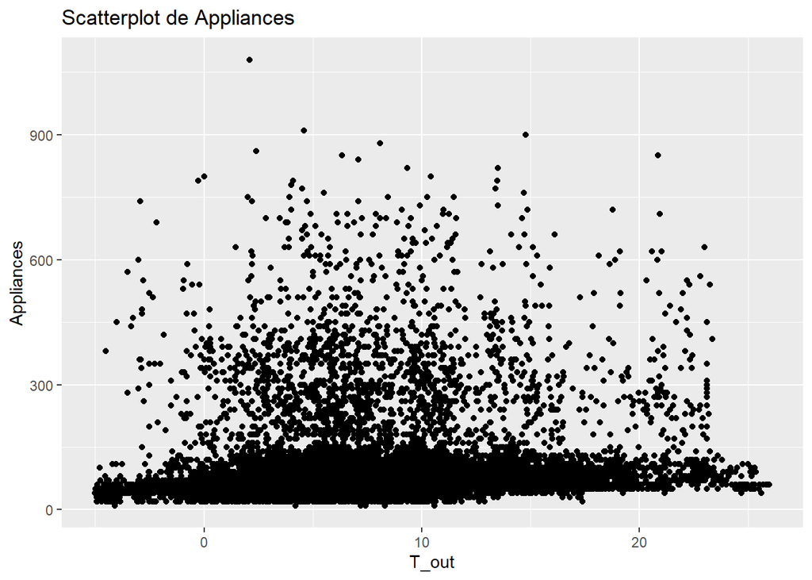

```r
# Gráfico Scatterplot Appliances
ggplot(data_train, aes(x = T_out, y = Appliances)) +
  geom_point() +
  labs(title = "Scatterplot de Appliances", x = "T_out", y = "Appliances")
```